# Bias in small populations

Andrea Brizzi

09/04/2021

While studying the effects of underreporting and missed generations, we noted that $R_0$ was underestimated by the different methods A possible rationale for this behaviour is that the efferctive reproduction number after 2 to 4 week has already had time to drop.

The objective of this markdown is to study wheter this reasoning is correct. To do so, we see wheter the estimate of $R_0$ are close to the effective reproduction number after 2 weeks, which is the starting date of the window used for estimation. In particular, in our simulation setting, we can take advantage of SEIR theory to compute $R_t$ as:
$$R_t = \frac{S_t}{S_0}R_0 = \left( 1 - \frac{\sum_{i<t} I_t }{S_0} \right) R_0.$$

## Settings

Again, we assume that we completely miss the first 2 generations and then start observing cases with a $50 \%$ reporting rate.

```r
sims_SEIR <- readRDS(file.path(data_path, "sims_SEIR"))
names <- names(sims_SEIR)[c(1,3,5,7)]

# generation interval parameters
mean_si <- 6.5
sd_si <- sqrt(3^2 + 3.5^2)

# reporting rate
pi <- 0.5
```

```r
# Problems showing plots: maybe store them in a list
list_plots <- list()
final_stats <- data.frame(method = as.character(),
                          coverage = as.numeric(),
                          scenario = as.character(),
                          CIwidth = as.numeric())

estimated_starts <- data.frame(scenario = as.character(),
                               estimate = as.numeric())

for (name in names){

  trueR0 <- as.numeric(stringr::str_match(name, "R0=\\s*(.*?)\\s*pop")[2])

  # Transform the data
  df <- as.data.frame(sims_SEIR[[name]])
  df$day <- 1:(dim(df)[1])

  results <- data.frame(sim = as.numeric(),
                        method = as.character(),
                        R0 = as.numeric(),
                        lowR0 = as.numeric(),
                        upR0 = as.numeric(),
                        trueRt = as.numeric()
                        )


  # For every possible simulation
  for(c in 1:(ncol(df - 1))){

    # compute true Rt at 2nd week (middle of window used)
    Rt_multiplier <- 1 - sum(df[1:14,c])/1000
    trueRt <- Rt_multiplier * trueR0

    # Get incidence
    incidence <- data.frame(cases = df[,c])
    incidence$cases <- rbinom(n = length(incidence$cases),
                              size = incidence$cases,
                              prob = pi)
    incidence$day <- 1:dim(incidence)[1]
    incidence <- filter(incidence, day > 14)

    # Make sure there are cases in the first 2 observed weeks...
    somecases <- (sum(incidence$cases[1:14]) >= 10)

    if (somecases){

      #== simple EpiEstim: biweekly sliding window
      epestim <- epiestim(incidence[1:14,], mean_GT = mean_si, sd_GT = sd_si)

      results <- rbind(results, data.frame(
        sim = c, method = 'simpleEpiEstim', R0 = epestim[1],
        lowR0 = epestim[2], upR0 = epestim[3],
        trueRt = trueRt
      ))


      #== Linear Exponential Growth: estimate using first 2 weeks
      if(any(incidence$cases==0)){
        incidence$casesC <- incidence$cases+0.5
        incidence$logcases <- log(incidence$casesC)
      }else{
        incidence$logcases <- log(incidence$cases)
      }

      eglin <- EG_Lin(data = incidence[1:14,], mean_GT = mean_si, sd_GT = sd_si)

      results <- rbind(results, data.frame(
        sim = c, method = 'EgLin', R0 = eglin[1],
        lowR0 = eglin[2], upR0 = eglin[3],
        trueRt = trueRt
      ))



      #== EpiEstim with corrections

      ## Only Megan's
      epestim2 <- epiestim_andrea(data = incidence[1:14,], mean_GT = mean_si, sd_GT = sd_si, andrea = FALSE)

      tmp <- data.frame(scenario = name,
                        estimate = epestim2$estimated_start)
      estimated_starts <- rbind(estimated_starts, tmp)

      epestim2 <- epestim2$results
      results <- rbind(results, data.frame(
          sim = c, method = 'EpiEstim_Megan', R0 = epestim2[1],
          lowR0 = epestim2[2], upR0 = epestim2[3],
          trueRt = trueRt
      ))

      ## Mine as well
      epestim2 <- epiestim_andrea(data = incidence[1:14,], mean_GT = mean_si, sd_GT = sd_si, andrea = TRUE)

      epestim2 <- epestim2$results
      results <- rbind(results, data.frame(
          sim = c, method = 'EpiEstim_Andrea', R0 = epestim2[1],
          lowR0 = epestim2[2], upR0 = epestim2[3],
          trueRt = trueRt
      ))

    }
    }


  rownames(results) <- c()


  results$method <- as.factor(results$method)
  results <- results %>% group_by(method)
  results$R0bias <- results$R0 - results$trueRt


  gg <- ggplot(data = results, aes(y = R0bias, x = method)) + geom_boxplot() +
    geom_hline(aes(yintercept = 0),col = "red", linetype = "dashed") + ggtitle(name)
  gg1 <- ggplot(data = results, aes(y = R0, x = method)) + geom_boxplot() +
    geom_hline(aes(yintercept = 1.5),col = "red", linetype = "dashed") + ggtitle(name)


  list_plots[[name]] <- gg

  results$inside <- (results$trueRt <= results$upR0 & results$trueRt >= results$lowR0)
  results$CIwidth <- results$upR0 - results$lowR0

  tmp <- results %>% group_by(method) %>%
    summarise(coverage = mean(inside), scenario = name, CIwidth = mean(CIwidth))

  final_stats <- rbind(final_stats, tmp)
}

knitr::kable(final_stats)
```

| method | coverage | scenario | CIwidth |
| --- | --- | --- | --- |
| EgLin | 0.9066667 | R0=1.5pop=10000 | 1.3521462 |
| EpiEstim_Andrea | 0.6533333 | R0=1.5pop=10000 | 1.1570741 |
| EpiEstim_Megan | 0.7333333 | R0=1.5pop=10000 | 1.4261619 |
| simpleEpiEstim | 0.6000000 | R0=1.5pop=10000 | 1.5376223 |
| EgLin | 0.8315789 | R0=2pop=10000 | 1.1744873 |
| EpiEstim_Andrea | 0.6631579 | R0=2pop=10000 | 0.8818106 |
| EpiEstim_Megan | 0.6421053 | R0=2pop=10000 | 0.9395939 |
| simpleEpiEstim | 0.3894737 | R0=2pop=10000 | 1.0490241 |
| EgLin | 0.8787879 | R0=2.5pop=10000 | 0.7509069 |
| EpiEstim_Andrea | 0.8484848 | R0=2.5pop=10000 | 0.5591296 |
| EpiEstim_Megan | 0.8484848 | R0=2.5pop=10000 | 0.5937766 |
| simpleEpiEstim | 0.2727273 | R0=2.5pop=10000 | 0.6592019 |
| EgLin | 0.9108911 | R0=3pop=10000 | 0.5817352 |
| EpiEstim_Andrea | 0.5940594 | R0=3pop=10000 | 0.3575146 |
| EpiEstim_Megan | 0.5940594 | R0=3pop=10000 | 0.3590245 |
| simpleEpiEstim | 0.3168317 | R0=3pop=10000 | 0.4039654 |

```
## $`R0=1.5pop=10000`
```

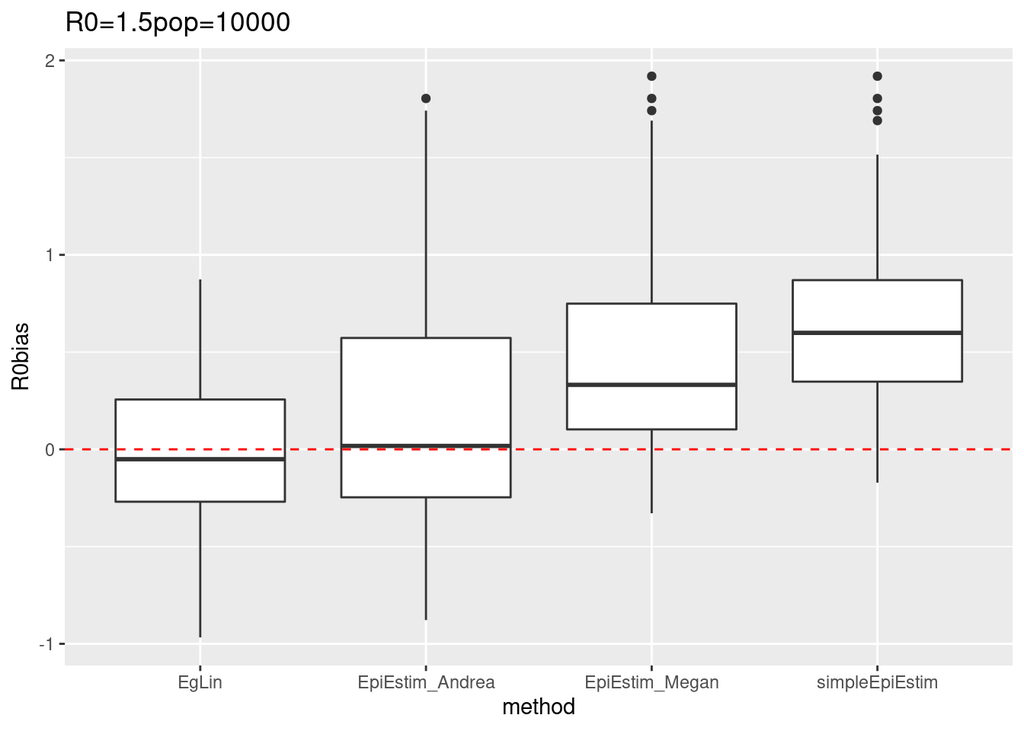

```
##
## $`R0=2pop=10000`
```

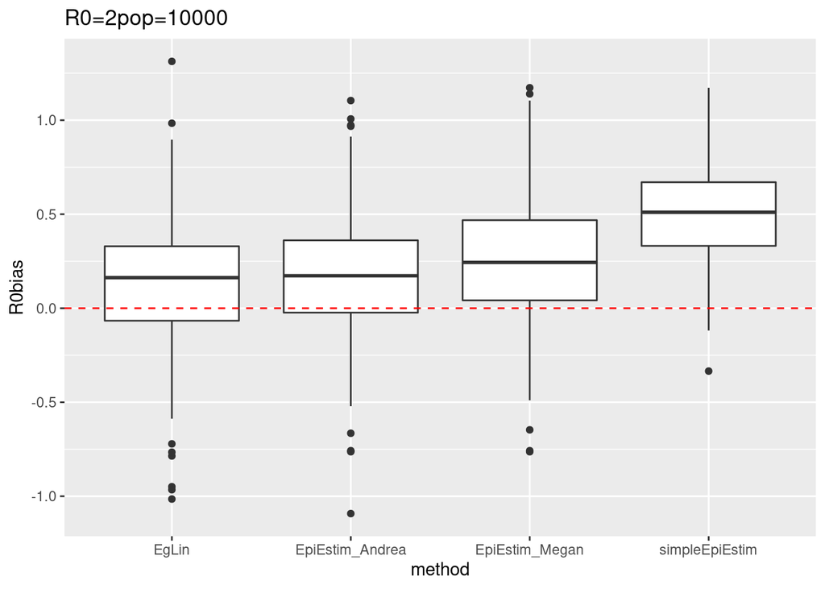

```
##
## $`R0=2.5pop=10000`
```

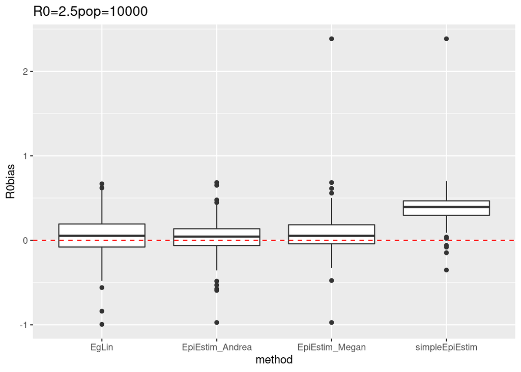

```
##
## $`R0=3pop=10000`
```

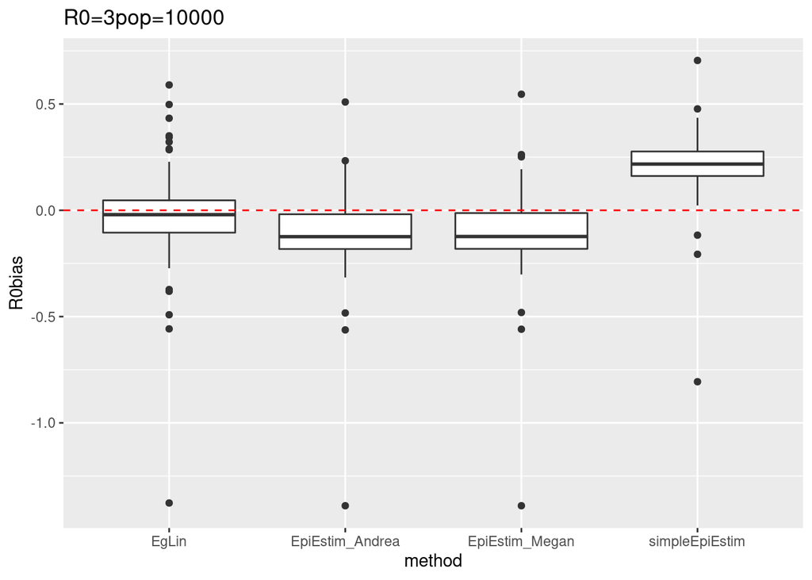

```r
list_plots
```